# Chapter 9 FMT

```r
load("data/data_27022025.Rdata")
load("data/calculations_28022025.Rdata")
```

## 9.1 FMT1

### 9.1.1 Is the GM of the intervention group more similar to warm population after one week from FMT?

#### 9.1.1.1 Shapiro test

```r
alpha_div %>%
  pivot_longer(-sample, names_to = "metric", values_to = "value") %>%
  left_join(., sample_metadata, by = join_by(sample == Tube_code)) %>%
  filter(time_point =="FMT1") %>%
  filter(metric=="richness") %>%
  summarize(shapiro_p_value = shapiro.test(value)$p.value) %>%
  pull(shapiro_p_value)
```

```
[1] 0.6077531
```

```r
alpha_div %>%
  pivot_longer(-sample, names_to = "metric", values_to = "value") %>%
  left_join(., sample_metadata, by = join_by(sample == Tube_code)) %>%
  filter(time_point =="FMT1") %>%
  filter(metric=="neutral") %>%
  summarize(shapiro_p_value = shapiro.test(value)$p.value) %>%
  pull(shapiro_p_value)
```

```
[1] 0.3357428
```

```r
alpha_div %>%
  pivot_longer(-sample, names_to = "metric", values_to = "value") %>%
  left_join(., sample_metadata, by = join_by(sample == Tube_code)) %>%
  filter(time_point =="FMT1") %>%
  filter(metric=="phylogenetic") %>%
  summarize(shapiro_p_value = shapiro.test(value)$p.value) %>%
  pull(shapiro_p_value)
```

```
[1] 0.9273925
```

#### 9.1.1.2 Alpha

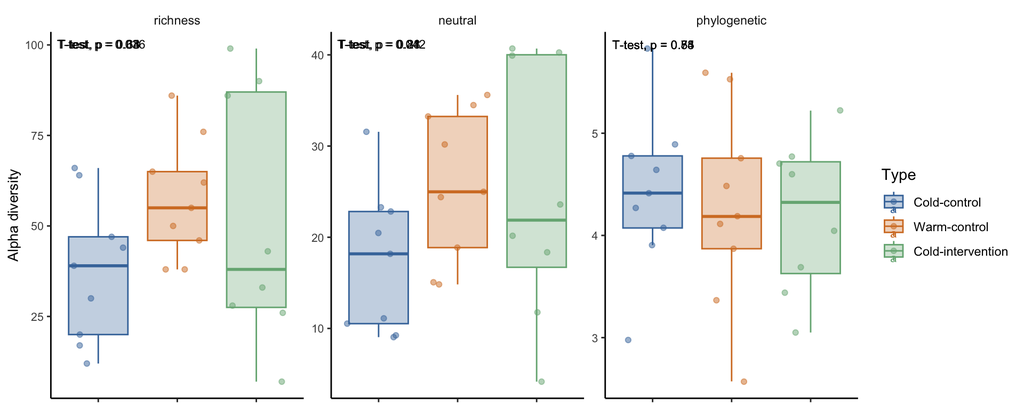

```r
alpha_div %>%
  pivot_longer(-sample, names_to = "metric", values_to = "value") %>%
  left_join(., sample_metadata, by = join_by(sample == Tube_code)) %>%
  filter(time_point=="FMT1") %>%
  mutate(metric=factor(metric,levels=c("richness","neutral","phylogenetic"))) %>%
      ggplot(aes(y = value, x = type, group=type, color=type, fill=type)) +
      geom_boxplot(outlier.shape = NA) +
      geom_jitter(alpha=0.5) +
      scale_color_manual(name="Type",
          breaks=c("Control","Hot_control", "Treatment"),
          labels=c("Cold-control","Warm-control", "Cold-intervention"),
          values=c("#4477AA","#d57d2c", "#76b183")) +
      scale_fill_manual(name="Type",
          breaks=c("Control","Hot_control", "Treatment"),
          labels=c("Cold-control","Warm-control", "Cold-intervention"),
          values=c("#4477AA50","#d57d2c50","#76b18350")) +
      facet_wrap(. ~ metric,scales = "free") +
      coord_cartesian(xlim = c(1, NA)) +
      stat_compare_means(method="t.test",size=3, label.x=.7) +
      theme_classic() +
        theme(
    strip.background = element_blank(),
    panel.grid.minor.x = element_line(size = .1, color = "grey"),
    axis.title.x = element_blank(),
    axis.title.y = element_text(size=10),
    axis.text.x = element_blank(),
    # Increase plot size
    plot.title = element_text(size = 10),
    axis.text = element_text(size = 8),
    axis.title = element_text(size = 8)
      ) +
  ylab("Alpha diversity")
```

***p<0.05 when comparing neutral beta diversity between Cold-control and Warm-control

#### 9.1.1.3 Beta diversity

*Number of samples used*

```r
samples_to_keep_post1 <- sample_metadata %>%
  filter(time_point == "FMT1") %>%
  select(Tube_code) %>%
  pull()
subset_meta_post1 <- sample_metadata %>%
  filter(time_point == "FMT1")
length(samples_to_keep_post1)
```

```
[1] 26
```

*Richness*

```r
richness_post1 <- as.matrix(beta_q0n$S)
richness_post1 <- as.dist(richness_post1[rownames(richness_post1) %in% samples_to_keep_post1,
               colnames(richness_post1) %in% samples_to_keep_post1])
betadisper(richness_post1, subset_meta_post1$type) %>% permutest(., pairwise = TRUE)
```

```
Permutation test for homogeneity of multivariate dispersions
Permutation: free
Number of permutations: 999

Response: Distances
          Df  Sum Sq   Mean Sq      F N.Perm Pr(>F)
Groups     2 0.01060 0.0052999 1.1619    999   0.38
Residuals 23 0.10491 0.0045613

Pairwise comparisons:
(Observed p-value below diagonal, permuted p-value above diagonal)
             Control Hot_control Treatment
Control                 0.046000     0.675
Hot_control 0.055742                 0.454
Treatment   0.625388    0.420078
```

```r
adonis2(richness_post1 ~ type,
        data = subset_meta_post1 %>% arrange(match(Tube_code,labels(richness_post1))),
        permutations = 999) %>%
        broom::tidy() %>%
        tt()
```

| term | df | SumOfSqs | R2 | statistic | p.value |
| --- | --- | --- | --- | --- | --- |
| Model | 2 | 1.195567 | 0.1448246 | 1.947534 | 0.002 |
| Residual | 23 | 7.059710 | 0.8551754 | NA | NA |
| Total | 25 | 8.255277 | 1.0000000 | NA | NA |

```r
subset_meta_post1_arrange <- column_to_rownames(subset_meta_post1, "Tube_code")
subset_meta_post1_arrange<-subset_meta_post1_arrange[labels(richness_post1),]

pairwise <- pairwise.adonis(richness_post1, subset_meta_post1_arrange$type, perm=999)
pairwise%>%
  tt()
```

| pairs | Df | SumsOfSqs | F.Model | R2 | p.value | p.adjusted | sig |
| --- | --- | --- | --- | --- | --- | --- | --- |
| Control vs Treatment | 1 | 0.5615418 | 1.729004 | 0.1033537 | 0.013 | 0.039 | . |
| Control vs Hot_control | 1 | 0.8438429 | 2.793772 | 0.1486541 | 0.002 | 0.006 | * |
| Treatment vs Hot_control | 1 | 0.3734921 | 1.268929 | 0.0779971 | 0.108 | 0.324 |  |

*Neutral*

```r
neutral_post1 <- as.matrix(beta_q1n$S)
neutral_post1 <- as.dist(neutral_post1[rownames(neutral_post1) %in% samples_to_keep_post1,
               colnames(neutral_post1) %in% samples_to_keep_post1])
betadisper(neutral_post1, subset_meta_post1$type) %>% permutest(., pairwise = TRUE)
```

```
Permutation test for homogeneity of multivariate dispersions
Permutation: free
Number of permutations: 999

Response: Distances
          Df   Sum Sq   Mean Sq      F N.Perm Pr(>F)
Groups     2 0.002996 0.0014982 0.1374    999  0.883
Residuals 23 0.250747 0.0109020

Pairwise comparisons:
(Observed p-value below diagonal, permuted p-value above diagonal)
            Control Hot_control Treatment
Control                 0.55300     0.877
Hot_control 0.55320                 0.784
Treatment   0.86589     0.76648
```

```r
adonis2(neutral_post1 ~ type,
        data = subset_meta_post1 %>% arrange(match(Tube_code,labels(neutral_post1))),
        permutations = 999) %>%
        broom::tidy() %>%
        tt()
```

| term | df | SumOfSqs | R2 | statistic | p.value |
| --- | --- | --- | --- | --- | --- |
| Model | 2 | 1.395968 | 0.1900228 | 2.697931 | 0.002 |
| Residual | 23 | 5.950350 | 0.8099772 | NA | NA |
| Total | 25 | 7.346318 | 1.0000000 | NA | NA |

```r
subset_meta_post1_arrange <- column_to_rownames(subset_meta_post1, "Tube_code")
subset_meta_post1_arrange<-subset_meta_post1_arrange[labels(neutral_post1),]
pairwise <- pairwise.adonis(neutral_post1, subset_meta_post1_arrange$type, perm=999)
pairwise%>%
  tt()
```

| pairs | Df | SumsOfSqs | F.Model | R2 | p.value | p.adjusted | sig |
| --- | --- | --- | --- | --- | --- | --- | --- |
| Control vs Treatment | 1 | 0.6051778 | 2.250849 | 0.13047758 | 0.013 | 0.039 | . |
| Control vs Hot_control | 1 | 1.0528902 | 4.143637 | 0.20570451 | 0.001 | 0.003 | * |
| Treatment vs Hot_control | 1 | 0.4150076 | 1.637268 | 0.09840968 | 0.047 | 0.141 |  |

*Phylogenetic*

```r
phylo_post1 <- as.matrix(beta_q1p$S)
phylo_post1 <- as.dist(phylo_post1[rownames(phylo_post1) %in% samples_to_keep_post1,
               colnames(phylo_post1) %in% samples_to_keep_post1])
betadisper(phylo_post1, subset_meta_post1$type) %>% permutest(., pairwise = TRUE)
```

```
Permutation test for homogeneity of multivariate dispersions
Permutation: free
Number of permutations: 999

Response: Distances
          Df  Sum Sq   Mean Sq      F N.Perm Pr(>F)
Groups     2 0.00399 0.0019943 0.1213    999  0.912
Residuals 23 0.37812 0.0164399

Pairwise comparisons:
(Observed p-value below diagonal, permuted p-value above diagonal)
            Control Hot_control Treatment
Control                 0.92600     0.710
Hot_control 0.91065                 0.775
Treatment   0.65272     0.74852
```

```r
adonis2(phylo_post1 ~ type,
        data = subset_meta_post1 %>% arrange(match(Tube_code,labels(phylo_post1))),
        permutations = 999) %>%
        broom::tidy() %>%
        tt()
```

| term | df | SumOfSqs | R2 | statistic | p.value |
| --- | --- | --- | --- | --- | --- |
| Model | 2 | 0.07451036 | 0.07059466 | 0.8735033 | 0.558 |
| Residual | 23 | 0.98095695 | 0.92940534 | NA | NA |
| Total | 25 | 1.05546731 | 1.00000000 | NA | NA |

```r
subset_meta_post1_arrange <- column_to_rownames(subset_meta_post1, "Tube_code")
subset_meta_post1_arrange<-subset_meta_post1_arrange[labels(phylo_post1),]
pairwise <- pairwise.adonis(phylo_post1, subset_meta_post1_arrange$type, perm=999)
pairwise%>%
  tt()
```

| pairs | Df | SumsOfSqs | F.Model | R2 | p.value | p.adjusted | sig |
| --- | --- | --- | --- | --- | --- | --- | --- |
| Control vs Treatment | 1 | 0.01842535 | 0.4144162 | 0.02688498 | 0.772 | 1.000 |  |
| Control vs Hot_control | 1 | 0.05987967 | 1.7387847 | 0.09802164 | 0.133 | 0.399 |  |
| Treatment vs Hot_control | 1 | 0.03212966 | 0.6477782 | 0.04139746 | 0.705 | 1.000 |  |

*NMDS*

```r
beta_richness_nmds_post1 <- richness_post1 %>%
                metaMDS(.,trymax = 500, k=2, verbosity=FALSE, trace = FALSE) %>%
                scores() %>%
                as_tibble(., rownames = "sample") %>%
                left_join(subset_meta_post1, by = join_by(sample == Tube_code)) %>%
            group_by(type) %>%
            mutate(x_cen = mean(NMDS1, na.rm = TRUE)) %>%
            mutate(y_cen = mean(NMDS2, na.rm = TRUE)) %>%
            ungroup() %>%
            ggplot(., aes(x=NMDS1,y=NMDS2, color=type)) +
        scale_color_manual(name="Type",
                       breaks=c("Control", "Hot_control", "Treatment"),
                       labels=c("Cold-Cold", "Hot-Hot", "Cold-Hot"),
                       values=c("#4477AA","#d57d2c","#76b183")) +
                geom_point(size=2) +
                geom_segment(aes(x=x_cen, y=y_cen, xend=NMDS1, yend=NMDS2), alpha=0.2) +
        labs(y = "NMDS2", x="NMDS1 \n Richness beta diversity") +
                theme_classic() +
                theme(legend.position="none")

beta_neutral_nmds_post1 <- neutral_post1 %>%
                metaMDS(.,trymax = 500, k=2, verbosity=FALSE, trace = FALSE) %>%
                scores() %>%
                as_tibble(., rownames = "sample") %>%
                left_join(subset_meta_post1, by = join_by(sample == Tube_code))%>%
            group_by(type) %>%
            mutate(x_cen = mean(NMDS1, na.rm = TRUE)) %>%
            mutate(y_cen = mean(NMDS2, na.rm = TRUE)) %>%
            ungroup() %>%
            ggplot(., aes(x=NMDS1,y=NMDS2, color=type)) +
        scale_color_manual(name="Type",
                       breaks=c("Control", "Hot_control", "Treatment"),
                       labels=c("Cold-Cold", "Hot-Hot", "Cold-Hot"),
                       values=c("#4477AA","#d57d2c","#76b183")) +
                geom_point(size=2) +
                geom_segment(aes(x=x_cen, y=y_cen, xend=NMDS1, yend=NMDS2), alpha=0.2) +
        labs(y = "NMDS2", x="NMDS1 \n Neutral beta diversity") +
                theme_classic() +
                theme(legend.position="none")

beta_phylogenetic_nmds_post1 <- phylo_post1 %>%
                metaMDS(.,trymax = 500, k=2, verbosity=FALSE, trace = FALSE) %>%
                scores() %>%
                as_tibble(., rownames = "sample") %>%
                left_join(subset_meta_post1, by = join_by(sample == Tube_code))%>%
            group_by(type) %>%
            mutate(x_cen = mean(NMDS1, na.rm = TRUE)) %>%
            mutate(y_cen = mean(NMDS2, na.rm = TRUE)) %>%
            ungroup() %>%
            ggplot(., aes(x=NMDS1,y=NMDS2, color=type)) +
                scale_color_manual(name="Type",
                       breaks=c("Control", "Hot_control", "Treatment"),
                       labels=c("Cold-Cold", "Hot-Hot", "Cold-Hot"),
                       values=c("#4477AA","#d57d2c","#76b183")) +
                geom_point(size=2) +
                geom_segment(aes(x=x_cen, y=y_cen, xend=NMDS1, yend=NMDS2), alpha=0.2) +
        labs(y= element_blank (), x="NMDS1 \n Phylogenetic beta diversity") +
                theme_classic() +
                theme(legend.position="none")
```

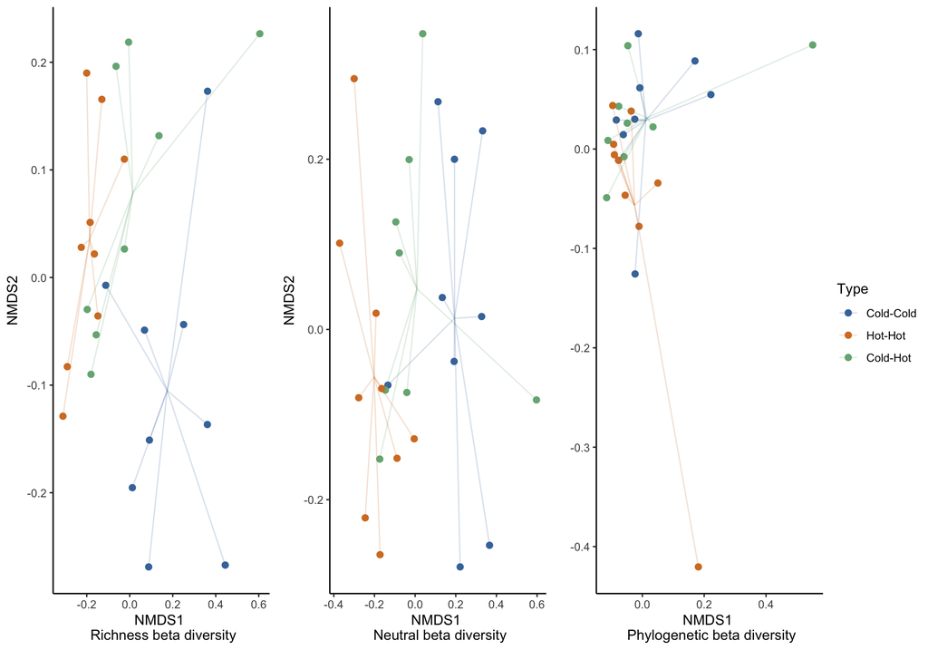

```r
ggarrange(beta_richness_nmds_post1, beta_neutral_nmds_post1, beta_phylogenetic_nmds_post1, ncol=3, nrow=1, common.legend = TRUE, legend="right")
```

#### 9.1.1.4 Differentially abundant MAGs

##### 9.1.1.4.1 Warm vs Intervention

```r
physeq_FMT1 <- subset_samples(physeq_all, type %in% c("Hot_control", "Treatment") & time_point == "FMT1")
physeq_FMT1 <- prune_taxa(taxa_sums(physeq_FMT1)>0, physeq_FMT1)
```

```r
ancom_rand_output_fmt1 = ancombc2(data = physeq_FMT1,
                  assay_name = "counts",
                  tax_level = NULL,
                  fix_formula = "type",
                  p_adj_method = "holm",
                  pseudo_sens = TRUE,
                  prv_cut =0,
                  lib_cut = 0,
                  s0_perc = 0.05,
                  group = "type",
                  struc_zero = TRUE,
                  neg_lb = FALSE,
                  alpha = 0.05,
                  n_cl = 2,
                  verbose = TRUE,
                  global = FALSE,
                  pairwise = FALSE,
                  dunnet = FALSE,
                  trend = FALSE,
                  iter_control = list(tol = 1e-5, max_iter = 20, verbose = FALSE),
                  em_control = list(tol = 1e-5, max_iter = 100),
                  mdfdr_control = list(fwer_ctrl_method = "holm", B = 100),
                  trend_control = NULL)
```

```r
save(ancom_rand_output_fmt1, file="data/ancom_rand_output_fmt1.RData")
```

```r
load("data/ancom_rand_output_fmt1.RData")
```

*Structural zeros*

```r
# Extract structural zeros
structural_zeros <- ancom_rand_output_fmt1$zero_ind

# Convert to a data frame for better readability
structural_zeros_df <- as.data.frame(structural_zeros) %>%
  column_to_rownames(., "taxon")

# Find taxa that are structural zeros in at least one group
structural_zero_taxa <- rownames(structural_zeros_df)[apply(structural_zeros_df, 1, any)]
length(structural_zero_taxa)
```

```
[1] 68
```

```r
ancom_rand_output_fmt1$res %>%
  dplyr::select(taxon, lfc_typeTreatment, p_typeTreatment) %>%
  filter(p_typeTreatment < 0.05)
```

```
                   taxon lfc_typeTreatment p_typeTreatment
1   AH1_2nd_2:bin_000001         1.5624677     0.018641387
2   LI1_2nd_9:bin_000007        -1.7396762     0.049924046
3  AH1_2nd_16:bin_000020         1.2543468     0.020997275
4   AH1_2nd_8:bin_000006        -1.4308506     0.037799325
5   AH1_2nd_1:bin_000023         1.6503345     0.002495972
6  AH1_2nd_16:bin_000058         1.3473611     0.022280401
7   AH1_2nd_2:bin_000017         1.7705419     0.024865927
8   LI1_2nd_8:bin_000019        -2.1022782     0.011005642
9   AH1_2nd_1:bin_000048         0.8195104     0.035758754
10  AH1_2nd_5:bin_000006         1.8686151     0.013777916
11 AH1_2nd_20:bin_000016        -1.4853429     0.016974603
12  LI1_2nd_4:bin_000003        -1.6188761     0.003324944
13 AH1_2nd_20:bin_000073        -1.9847277     0.049409557
```

```
                   taxon lfc_typeTreatment p_typeTreatment      domain           phylum                  class                order              family                 genus                           species
1   LI1_2nd_8:bin_000019        -2.1022782     0.011005642 d__Bacteria      Bacillota_A          c__Clostridia   Christensenellales             UBA3700
2  AH1_2nd_20:bin_000073        -1.9847277     0.049409557 d__Bacteria        Bacillota             c__Bacilli      Lactobacillales     Enterococcaceae          Enterococcus          Enterococcus sp002174455
3   LI1_2nd_9:bin_000007        -1.7396762     0.049924046 d__Bacteria   Pseudomonadota c__Alphaproteobacteria                 RF32             CAG-239              CAJLXD01
4   LI1_2nd_4:bin_000003        -1.6188761     0.003324944 d__Bacteria        Bacillota             c__Bacilli   Erysipelotrichales Erysipelotrichaceae                Dielma
5  AH1_2nd_20:bin_000016        -1.4853429     0.016974603 d__Bacteria        Bacillota             c__Bacilli   Erysipelotrichales Erysipelotrichaceae
6   AH1_2nd_8:bin_000006        -1.4308506     0.037799325 d__Bacteria      Bacillota_A          c__Clostridia       Lachnospirales     Lachnospiraceae                CAG-95
7   AH1_2nd_1:bin_000048         0.8195104     0.035758754 d__Bacteria      Bacillota_A          c__Clostridia Peptostreptococcales    Anaerovoracaceae
8  AH1_2nd_16:bin_000020         1.2543468     0.020997275 d__Bacteria Desulfobacterota    c__Desulfovibrionia   Desulfovibrionales Desulfovibrionaceae             Bilophila
9  AH1_2nd_16:bin_000058         1.3473611     0.022280401 d__Bacteria      Bacillota_A          c__Clostridia       Lachnospirales     Lachnospiraceae         Enterocloster
10  AH1_2nd_2:bin_000001         1.5624677     0.018641387 d__Bacteria     Bacteroidota         c__Bacteroidia        Bacteroidales      Bacteroidaceae
11  AH1_2nd_1:bin_000023         1.6503345     0.002495972 d__Bacteria      Bacillota_A          c__Clostridia       Lachnospirales     Lachnospiraceae
12  AH1_2nd_2:bin_000017         1.7705419     0.024865927 d__Bacteria      Bacillota_A          c__Clostridia       Lachnospirales     Lachnospiraceae            Copromonas
13  AH1_2nd_5:bin_000006         1.8686151     0.013777916 d__Bacteria      Bacillota_C       c__Negativicutes    Acidaminococcales  Acidaminococcaceae Phascolarctobacterium Phascolarctobacterium sp900544795
```

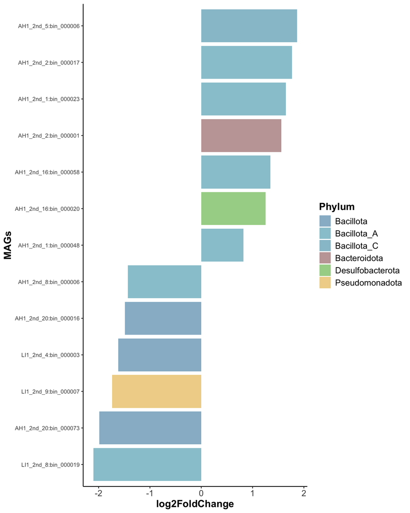

```r
ancombc_rand_table_mag%>%
  filter(lfc_typeTreatment>0)  %>%
  count(phylum, name = "sample_count") %>%
  arrange(desc(sample_count))
```

```
            phylum sample_count
1      Bacillota_A            4
2      Bacillota_C            1
3     Bacteroidota            1
4 Desulfobacterota            1
```

```r
ancombc_rand_table_mag%>%
  filter(lfc_typeTreatment<0)  %>%
  count(phylum, name = "sample_count") %>%
  arrange(desc(sample_count))
```

```
          phylum sample_count
1      Bacillota            3
2    Bacillota_A            2
3 Pseudomonadota            1
```

##### 9.1.1.4.2 Intervention vs cold control

```r
physeq_FMT1_cold <- subset_samples(physeq_all, type %in% c("Control", "Treatment") & time_point == "FMT1")
physeq_FMT1_cold <- prune_taxa(taxa_sums(physeq_FMT1_cold)>0, physeq_FMT1_cold)
```

```r
ancom_rand_output_cold = ancombc2(data = physeq_FMT1_cold,
                  assay_name = "counts",
                  tax_level = NULL,
                  fix_formula = "type",
                  p_adj_method = "holm",
                  pseudo_sens = TRUE,
                  prv_cut =0,
                  lib_cut = 0,
                  s0_perc = 0.05,
                  group = "type",
                  struc_zero = TRUE,
                  neg_lb = FALSE,
                  alpha = 0.05,
                  n_cl = 2,
                  verbose = TRUE,
                  global = FALSE,
                  pairwise = FALSE,
                  dunnet = FALSE,
                  trend = FALSE,
                  iter_control = list(tol = 1e-5, max_iter = 20, verbose = FALSE),
                  em_control = list(tol = 1e-5, max_iter = 100),
                  mdfdr_control = list(fwer_ctrl_method = "holm", B = 100),
                  trend_control = NULL)
```

```r
save(ancom_rand_output_cold, file="data/ancom_rand_output_cold.RData")
```

```r
load("data/ancom_rand_output_cold.RData")
```

*Structural zeros*

```r
# Extract structural zeros
structural_zeros <- ancom_rand_output_cold$zero_ind

# Convert to a data frame for better readability
structural_zeros_df <- as.data.frame(structural_zeros) %>%
  column_to_rownames(., "taxon")

# Find taxa that are structural zeros in at least one group
structural_zero_taxa <- rownames(structural_zeros_df)[apply(structural_zeros_df, 1, any)]
length(structural_zero_taxa)
```

```
[1] 82
```

```r
ancom_rand_output_cold$res %>%
  dplyr::select(taxon, lfc_typeTreatment, p_typeTreatment) %>%
  filter(p_typeTreatment < 0.05)
```

```
                   taxon lfc_typeTreatment p_typeTreatment
1  AH1_2nd_14:bin_000052        -1.2669085     0.015778542
2  AH1_2nd_11:bin_000028        -1.0321400     0.037820661
3  AH1_2nd_19:bin_000055        -0.9895362     0.027743640
4  AH1_2nd_10:bin_000049        -1.5258430     0.008213943
5   AH1_2nd_7:bin_000003        -1.5870692     0.009497131
6   AH1_2nd_7:bin_000036        -0.9815246     0.033968196
7   AH1_2nd_7:bin_000006        -1.3260451     0.031035777
8  AH1_2nd_15:bin_000013        -1.2001345     0.030031400
9  AH1_2nd_16:bin_000023        -1.7676743     0.021585294
10  AH1_2nd_7:bin_000055        -0.9341728     0.022662083
11 AH1_2nd_20:bin_000073         1.3651254     0.049079318
```

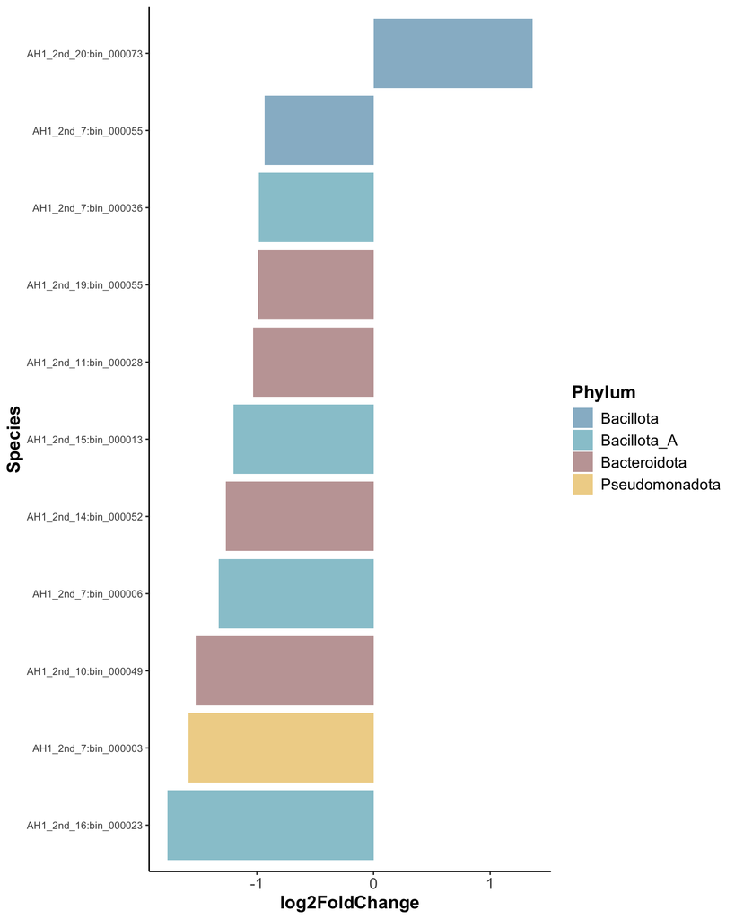

*Phyla of the significant MAGs in intervention group*

```r
ancombc_rand_table_mag%>%
  filter(lfc_typeTreatment>0)  %>%
  count(phylum, name = "sample_count") %>%
  arrange(desc(sample_count))
```

```
     phylum sample_count
1 Bacillota            1
```

*Phyla of the significant MAGs in cold control*

```r
ancombc_rand_table_mag%>%
  filter(lfc_typeTreatment<0)  %>%
  count(phylum, name = "sample_count") %>%
  arrange(desc(sample_count))
```

```
          phylum sample_count
1    Bacillota_A            4
2   Bacteroidota            4
3      Bacillota            1
4 Pseudomonadota            1
```

#### 9.1.1.5 Functional differences

*MCI*

```r
GIFTs_functions_community %>%
  rowMeans() %>%
  as_tibble(., rownames = "sample") %>%
  left_join(sample_metadata, by = join_by(sample == Tube_code)) %>%
  filter(time_point=="FMT1") %>%
  group_by(type) %>%
  summarise(MCI = mean(value), sd = sd(value))
```

```
# A tibble: 3 × 3
  type          MCI     sd
  <chr>       <dbl>  <dbl>
1 Control     0.373 0.0247
2 Hot_control 0.372 0.0367
3 Treatment   0.353 0.0186
```

```r
MCI_tm5_ele <- GIFTs_functions_community %>%
  rowMeans() %>%
  as_tibble(., rownames = "sample") %>%
  left_join(sample_metadata, by = join_by(sample == Tube_code)) %>%
  filter(time_point == "FMT1")

shapiro.test(MCI_tm5_ele$value)#normality test
```

```
    Shapiro-Wilk normality test

data:  MCI_tm5_ele$value
W = 0.92343, p-value = 0.05415
```

```r
res.aov <- aov(value ~ type, data = MCI_tm5_ele)#anova test
summary(res.aov)
```

```
            Df  Sum Sq   Mean Sq F value Pr(>F)
type         2 0.00216 0.0010798   1.371  0.274
Residuals   23 0.01811 0.0007875
```

*Functional differences*

CC and CI

```r
element_gift %>%
  filter(type %in% c("Control", "Treatment") & time_point == "FMT1") %>%
  select(-time_point, -type) %>%
  filter(rowSums(across(where(is.numeric), ~ . != 0)) > 0) %>%
  select(Tube_code, where( ~ is.numeric(.) && sum(.) > 0)) %>%
  left_join(sample_metadata[c(1, 7)], by = "Tube_code") %>%
  pivot_longer(-c(Tube_code, type),
               names_to = "trait",
               values_to = "value") %>%
  group_by(trait) %>%
  summarise(p_value = wilcox.test(value ~ type)$p.value) %>%
  mutate(p_adjust = p.adjust(p_value, method = "BH")) %>%
  filter(p_adjust < 0.05) %>%
  remove_rownames()
```

```
# A tibble: 0 × 3
# ℹ 3 variables: trait <chr>, p_value <dbl>, p_adjust <dbl>
```

CI and WC

```r
element_gift %>%
  filter(type %in% c("Hot_control", "Treatment") &
           time_point == "FMT1") %>%
  select(-time_point, -type) %>%
  filter(rowSums(across(where(is.numeric), ~ . != 0)) > 0) %>%
  select(Tube_code, where(~ is.numeric(.) && sum(.) > 0)) %>%
  left_join(sample_metadata[c(1, 7)], by = "Tube_code") %>%
  pivot_longer(-c(Tube_code,type), names_to = "trait", values_to = "value") %>%
  group_by(trait) %>%
  summarise(p_value = wilcox.test(value ~ type)$p.value) %>%
  mutate(p_adjust=p.adjust(p_value, method="BH")) %>%
  filter(p_adjust < 0.05)%>%
  remove_rownames()
```

```
# A tibble: 0 × 3
# ℹ 3 variables: trait <chr>, p_value <dbl>, p_adjust <dbl>
```

CC and WC

```r
element_gift %>%
  filter(type %in% c("Hot_control", "Control") &
           time_point == "FMT1") %>%
  select(-time_point, -type) %>%
  filter(rowSums(across(where(is.numeric), ~ . != 0)) > 0) %>%
  select(Tube_code, where(~ is.numeric(.) && sum(.) > 0)) %>%
  left_join(sample_metadata[c(1, 7)], by = "Tube_code") %>%
  pivot_longer(-c(Tube_code,type), names_to = "trait", values_to = "value") %>%
  group_by(trait) %>%
  summarise(p_value = wilcox.test(value ~ type)$p.value) %>%
  mutate(p_adjust=p.adjust(p_value, method="BH")) %>%
  filter(p_adjust < 0.05)%>%
  remove_rownames()
```

```
# A tibble: 0 × 3
# ℹ 3 variables: trait <chr>, p_value <dbl>, p_adjust <dbl>
```

## 9.2 FMT2

### 9.2.1 Is the GM of the intervention group still more similar to warm population after one week from FMT?

#### 9.2.1.1 Shapiro test

```r
alpha_div %>%
  pivot_longer(-sample, names_to = "metric", values_to = "value") %>%
  left_join(., sample_metadata, by = join_by(sample == Tube_code)) %>%
  filter(time_point =="FMT2") %>%
  filter(metric=="richness") %>%
  summarize(shapiro_p_value = shapiro.test(value)$p.value) %>%
  pull(shapiro_p_value)
```

```
[1] 0.1683943
```

```r
alpha_div %>%
  pivot_longer(-sample, names_to = "metric", values_to = "value") %>%
  left_join(., sample_metadata, by = join_by(sample == Tube_code)) %>%
  filter(time_point =="FMT2") %>%
  filter(metric=="neutral") %>%
  summarize(shapiro_p_value = shapiro.test(value)$p.value) %>%
  pull(shapiro_p_value)
```

```
[1] 0.6310339
```

```r
alpha_div %>%
  pivot_longer(-sample, names_to = "metric", values_to = "value") %>%
  left_join(., sample_metadata, by = join_by(sample == Tube_code)) %>%
  filter(time_point =="FMT2") %>%
  filter(metric=="phylogenetic") %>%
  summarize(shapiro_p_value = shapiro.test(value)$p.value) %>%
  pull(shapiro_p_value)
```

```
[1] 0.3446539
```

#### 9.2.1.2 Alpha

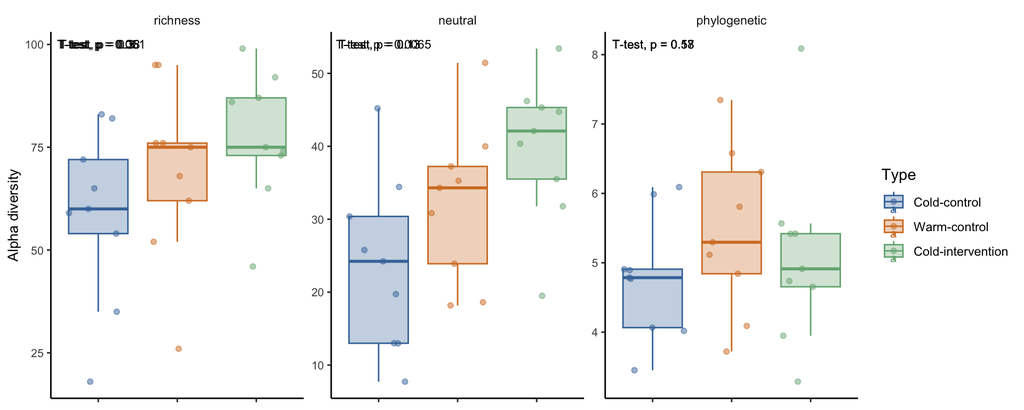

```r
alpha_div %>%
  pivot_longer(-sample, names_to = "metric", values_to = "value") %>%
  left_join(., sample_metadata, by = join_by(sample == Tube_code)) %>%
  filter(time_point=="FMT2") %>%
  mutate(metric=factor(metric,levels=c("richness","neutral","phylogenetic"))) %>%
      ggplot(aes(y = value, x = type, group=type, color=type, fill=type)) +
      geom_boxplot(outlier.shape = NA) +
      geom_jitter(alpha=0.5) +
      scale_color_manual(name="Type",
          breaks=c("Control","Hot_control", "Treatment"),
          labels=c("Cold-control","Warm-control", "Cold-intervention"),
          values=c("#4477AA","#d57d2c", "#76b183")) +
      scale_fill_manual(name="Type",
          breaks=c("Control","Hot_control", "Treatment"),
          labels=c("Cold-control","Warm-control", "Cold-intervention"),
          values=c("#4477AA50","#d57d2c50","#76b18350")) +
        scale_x_discrete(labels = c("Control" = "Cold-Cold", "Hot_control" = "Hot-Hot", "Treatment" = "Cold-Hot")) +
      facet_wrap(. ~ metric,scales = "free") +
      coord_cartesian(xlim = c(1, NA)) +
      stat_compare_means(method="t.test",size=3, label.x=.7) +
      theme_classic() +
        theme(
    strip.background = element_blank(),
    panel.grid.minor.x = element_line(size = .1, color = "grey"),
    axis.title.x = element_blank(),
    axis.title.y = element_text(size=10),
    axis.text.x = element_blank(),
    # Increase plot size
    plot.title = element_text(size = 10),
    axis.text = element_text(size = 8),
    axis.title = element_text(size = 8)
      ) +
  ylab("Alpha diversity")
```

***p<0.05 when comparing richness and neutral beta diversity between Cold-control and Cold-intervention

#### 9.2.1.3 Beta diversity

*Number of samples used*

```r
samples_to_keep_FMT2 <- sample_metadata %>%
  filter(time_point == "FMT2") %>%
  select(Tube_code) %>%
  pull()
subset_meta_FMT2 <- sample_metadata %>%
  filter(time_point == "FMT2")
length(samples_to_keep_FMT2)
```

```
[1] 27
```

*Richness*

```r
richness_FMT2 <- as.matrix(beta_q0n$S)
richness_FMT2 <- as.dist(richness_FMT2[rownames(richness_FMT2) %in% samples_to_keep_FMT2,
               colnames(richness_FMT2) %in% samples_to_keep_FMT2])
betadisper(richness_FMT2, subset_meta_FMT2$type) %>% permutest(., pairwise = TRUE)
```

```
Permutation test for homogeneity of multivariate dispersions
Permutation: free
Number of permutations: 999

Response: Distances
          Df   Sum Sq   Mean Sq      F N.Perm Pr(>F)
Groups     2 0.003043 0.0015214 0.2578    999  0.778
Residuals 24 0.141630 0.0059013

Pairwise comparisons:
(Observed p-value below diagonal, permuted p-value above diagonal)
            Control Hot_control Treatment
Control                 0.94000     0.532
Hot_control 0.93628                 0.538
Treatment   0.50455     0.54043
```

```r
adonis2(richness_FMT2 ~ type,
        data = subset_meta_FMT2 %>% arrange(match(Tube_code,labels(richness_FMT2))),
        permutations = 999) %>%
        broom::tidy() %>%
        tt()
```

| term | df | SumOfSqs | R2 | statistic | p.value |
| --- | --- | --- | --- | --- | --- |
| Model | 2 | 1.504341 | 0.1967776 | 2.939822 | 0.001 |
| Residual | 24 | 6.140538 | 0.8032224 | NA | NA |
| Total | 26 | 7.644879 | 1.0000000 | NA | NA |

```r
subset_meta_FMT2_arrange <- column_to_rownames(subset_meta_FMT2, "Tube_code")
subset_meta_FMT2_arrange<-subset_meta_FMT2_arrange[labels(richness_FMT2),]

pairwise <- pairwise.adonis(richness_FMT2, subset_meta_FMT2_arrange$type, perm=999)
pairwise%>%
  tt()
```

| pairs | Df | SumsOfSqs | F.Model | R2 | p.value | p.adjusted | sig |
| --- | --- | --- | --- | --- | --- | --- | --- |
| Control vs Treatment | 1 | 0.6463814 | 2.560441 | 0.1379515 | 0.002 | 0.006 | * |
| Control vs Hot_control | 1 | 1.1305044 | 4.268317 | 0.2105906 | 0.001 | 0.003 | * |
| Treatment vs Hot_control | 1 | 0.4796256 | 1.916520 | 0.1069694 | 0.001 | 0.003 | * |

*Neutral*

```r
neutral_FMT2 <- as.matrix(beta_q1n$S)
neutral_FMT2 <- as.dist(neutral_FMT2[rownames(neutral_FMT2) %in% samples_to_keep_FMT2,
               colnames(neutral_FMT2) %in% samples_to_keep_FMT2])
betadisper(neutral_FMT2, subset_meta_FMT2$type) %>% permutest(., pairwise = TRUE)
```

```
Permutation test for homogeneity of multivariate dispersions
Permutation: free
Number of permutations: 999

Response: Distances
          Df   Sum Sq   Mean Sq     F N.Perm Pr(>F)
Groups     2 0.005365 0.0026827 0.309    999  0.766
Residuals 24 0.208332 0.0086805

Pairwise comparisons:
(Observed p-value below diagonal, permuted p-value above diagonal)
            Control Hot_control Treatment
Control                 0.75500     0.676
Hot_control 0.75233                 0.455
Treatment   0.64640     0.46107
```

```r
adonis2(neutral_FMT2 ~ type,
        data = subset_meta_FMT2 %>% arrange(match(Tube_code,labels(neutral_FMT2))),
        permutations = 999) %>%
        broom::tidy() %>%
        tt()
```

| term | df | SumOfSqs | R2 | statistic | p.value |
| --- | --- | --- | --- | --- | --- |
| Model | 2 | 1.923807 | 0.2603795 | 4.224537 | 0.001 |
| Residual | 24 | 5.464666 | 0.7396205 | NA | NA |
| Total | 26 | 7.388473 | 1.0000000 | NA | NA |

```r
subset_meta_FMT2_arrange <- column_to_rownames(subset_meta_FMT2, "Tube_code")
subset_meta_FMT2_arrange<-subset_meta_FMT2_arrange[labels(neutral_FMT2),]
pairwise <- pairwise.adonis(neutral_FMT2, subset_meta_FMT2_arrange$type, perm=999)
pairwise%>%
  tt()
```

| pairs | Df | SumsOfSqs | F.Model | R2 | p.value | p.adjusted | sig |
| --- | --- | --- | --- | --- | --- | --- | --- |
| Control vs Treatment | 1 | 1.0227481 | 4.648335 | 0.2251191 | 0.001 | 0.003 | * |
| Control vs Hot_control | 1 | 1.3619424 | 5.771031 | 0.2650785 | 0.001 | 0.003 | * |
| Treatment vs Hot_control | 1 | 0.5010202 | 2.206532 | 0.1211945 | 0.003 | 0.009 | * |

*Phylogenetic*

```r
phylo_FMT2 <- as.matrix(beta_q1p$S)
phylo_FMT2 <- as.dist(phylo_FMT2[rownames(phylo_FMT2) %in% samples_to_keep_FMT2,
               colnames(phylo_FMT2) %in% samples_to_keep_FMT2])
betadisper(phylo_FMT2, subset_meta_FMT2$type) %>% permutest(., pairwise = TRUE)
```

```
Permutation test for homogeneity of multivariate dispersions
Permutation: free
Number of permutations: 999

Response: Distances
          Df   Sum Sq   Mean Sq      F N.Perm Pr(>F)
Groups     2 0.002880 0.0014398 0.3483    999  0.684
Residuals 24 0.099207 0.0041336

Pairwise comparisons:
(Observed p-value below diagonal, permuted p-value above diagonal)
            Control Hot_control Treatment
Control                 0.80100     0.609
Hot_control 0.79696                 0.398
Treatment   0.60817     0.41749
```

```r
adonis2(phylo_FMT2 ~ type,
        data = subset_meta_FMT2 %>% arrange(match(Tube_code,labels(phylo_FMT2))),
        permutations = 999) %>%
        broom::tidy() %>%
        tt()
```

| term | df | SumOfSqs | R2 | statistic | p.value |
| --- | --- | --- | --- | --- | --- |
| Model | 2 | 0.1594363 | 0.2042241 | 3.079623 | 0.001 |
| Residual | 24 | 0.6212564 | 0.7957759 | NA | NA |
| Total | 26 | 0.7806927 | 1.0000000 | NA | NA |

```r
subset_meta_FMT2_arrange <- column_to_rownames(subset_meta_FMT2, "Tube_code")
subset_meta_FMT2_arrange<-subset_meta_FMT2_arrange[labels(phylo_FMT2),]
pairwise <- pairwise.adonis(phylo_FMT2, subset_meta_FMT2_arrange$type, perm=999)
pairwise%>%
  tt()
```

| pairs | Df | SumsOfSqs | F.Model | R2 | p.value | p.adjusted | sig |
| --- | --- | --- | --- | --- | --- | --- | --- |
| Control vs Treatment | 1 | 0.05927454 | 2.382025 | 0.1295845 | 0.029 | 0.087 |  |
| Control vs Hot_control | 1 | 0.11081709 | 4.043656 | 0.2017424 | 0.002 | 0.006 | * |
| Treatment vs Hot_control | 1 | 0.06906280 | 2.722460 | 0.1454115 | 0.002 | 0.006 | * |

*NMDS*

```r
beta_richness_nmds_FMT2 <- richness_FMT2 %>%
                metaMDS(.,trymax = 500, k=2, verbosity=FALSE, trace = FALSE) %>%
                scores() %>%
                as_tibble(., rownames = "sample") %>%
                left_join(subset_meta_FMT2, by = join_by(sample == Tube_code)) %>%
            group_by(type) %>%
            mutate(x_cen = mean(NMDS1, na.rm = TRUE)) %>%
            mutate(y_cen = mean(NMDS2, na.rm = TRUE)) %>%
            ungroup() %>%
            ggplot(., aes(x=NMDS1,y=NMDS2, color=type)) +
        scale_color_manual(name="Type",
                       breaks=c("Control", "Hot_control", "Treatment"),
                       labels=c("Cold-Cold", "Hot-Hot", "Cold-Hot"),
                       values=c("#4477AA","#d57d2c","#76b183")) +
                geom_point(size=2) +
                geom_segment(aes(x=x_cen, y=y_cen, xend=NMDS1, yend=NMDS2), alpha=0.2) +
        labs(y = "NMDS2", x="NMDS1 \n Richness beta diversity") +
                theme_classic() +
                theme(legend.position="none")

beta_neutral_nmds_FMT2 <- neutral_FMT2 %>%
                metaMDS(.,trymax = 500, k=2, verbosity=FALSE, trace = FALSE) %>%
                scores() %>%
                as_tibble(., rownames = "sample") %>%
                left_join(subset_meta_FMT2, by = join_by(sample == Tube_code))%>%
            group_by(type) %>%
            mutate(x_cen = mean(NMDS1, na.rm = TRUE)) %>%
            mutate(y_cen = mean(NMDS2, na.rm = TRUE)) %>%
            ungroup() %>%
            ggplot(., aes(x=NMDS1,y=NMDS2, color=type)) +
        scale_color_manual(name="Type",
                       breaks=c("Control", "Hot_control", "Treatment"),
                       labels=c("Cold-Cold", "Hot-Hot", "Cold-Hot"),
                       values=c("#4477AA","#d57d2c","#76b183")) +
                geom_point(size=2) +
                geom_segment(aes(x=x_cen, y=y_cen, xend=NMDS1, yend=NMDS2), alpha=0.2) +
        labs(y = "NMDS2", x="NMDS1 \n Neutral beta diversity") +
                theme_classic() +
                theme(legend.position="none")

beta_phylogenetic_nmds_FMT2 <- phylo_FMT2 %>%
                metaMDS(.,trymax = 500, k=2, verbosity=FALSE, trace = FALSE) %>%
                scores() %>%
                as_tibble(., rownames = "sample") %>%
                left_join(subset_meta_FMT2, by = join_by(sample == Tube_code))%>%
            group_by(type) %>%
            mutate(x_cen = mean(NMDS1, na.rm = TRUE)) %>%
            mutate(y_cen = mean(NMDS2, na.rm = TRUE)) %>%
            ungroup() %>%
            ggplot(., aes(x=NMDS1,y=NMDS2, color=type)) +
                scale_color_manual(name="Type",
                       breaks=c("Control", "Hot_control", "Treatment"),
                       labels=c("Cold-Cold", "Hot-Hot", "Cold-Hot"),
                       values=c("#4477AA","#d57d2c","#76b183")) +
                geom_point(size=2) +
                geom_segment(aes(x=x_cen, y=y_cen, xend=NMDS1, yend=NMDS2), alpha=0.2) +
        labs(y= element_blank (), x="NMDS1 \n Phylogenetic beta diversity") +
                theme_classic() +
                theme(legend.position="none")
```

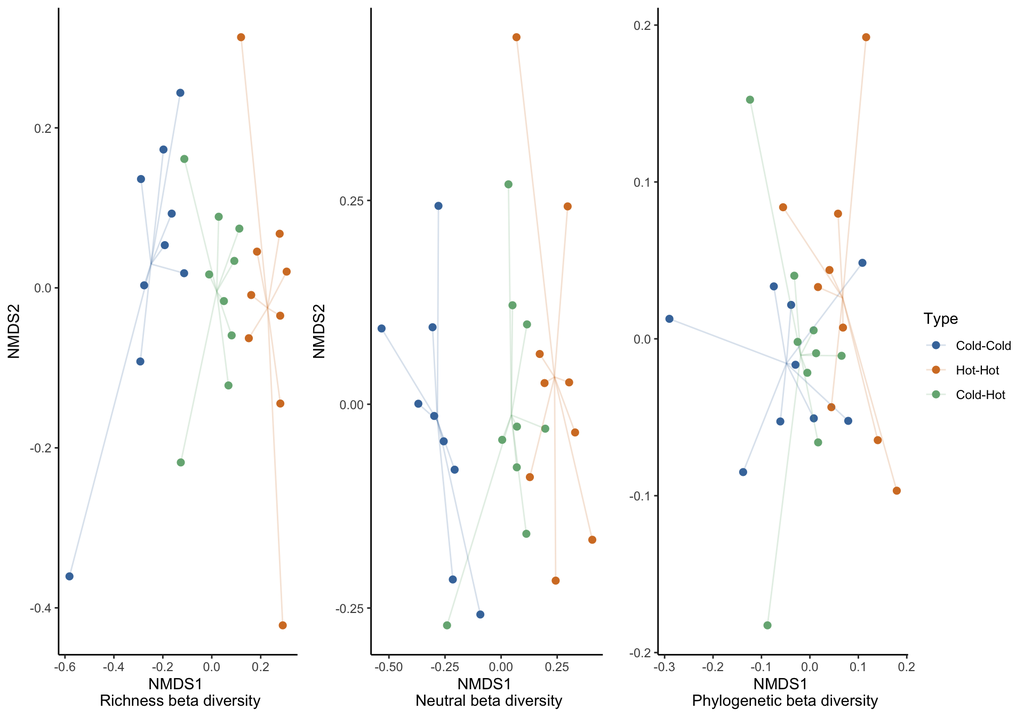

```r
ggarrange(beta_richness_nmds_FMT2, beta_neutral_nmds_FMT2, beta_phylogenetic_nmds_FMT2, ncol=3, nrow=1, common.legend = TRUE, legend="right")
```

#### 9.2.1.4 Differentially abundant MAGs

##### 9.2.1.4.1 Warm vs Intervention

```r
physeq_FMT2 <- subset_samples(physeq_all, type %in% c("Hot_control", "Treatment") & time_point == "FMT2")
physeq_FMT2 <- prune_taxa(taxa_sums(physeq_FMT2)>0, physeq_FMT2)
```

```r
ancom_rand_output_fmt2 = ancombc2(data = physeq_FMT2,
                  assay_name = "counts",
                  tax_level = NULL,
                  fix_formula = "type",
                  p_adj_method = "holm",
                  pseudo_sens = TRUE,
                  prv_cut =0,
                  lib_cut = 0,
                  s0_perc = 0.05,
                  group = "type",
                  struc_zero = TRUE,
                  neg_lb = FALSE,
                  alpha = 0.05,
                  n_cl = 2,
                  verbose = TRUE,
                  global = FALSE,
                  pairwise = FALSE,
                  dunnet = FALSE,
                  trend = FALSE,
                  iter_control = list(tol = 1e-5, max_iter = 20, verbose = FALSE),
                  em_control = list(tol = 1e-5, max_iter = 100),
                  mdfdr_control = list(fwer_ctrl_method = "holm", B = 100),
                  trend_control = NULL)
```

```r
save(ancom_rand_output_fmt2, file="data/ancom_rand_output_fmt2.RData")
```

```r
load("data/ancom_rand_output_fmt2.RData")
ancom_rand_output_fmt2$res %>%
  dplyr::select(taxon, lfc_typeTreatment, p_typeTreatment) %>%
  filter(p_typeTreatment < 0.05)
```

```
                   taxon lfc_typeTreatment p_typeTreatment
1   LI1_2nd_5:bin_000037        -1.0679498     0.009253269
2   AH1_2nd_6:bin_000037        -2.1330510     0.003515889
3  AH1_2nd_16:bin_000019        -1.2303114     0.040435884
4  AH1_2nd_11:bin_000028         1.2508603     0.003488718
5   LI1_2nd_4:bin_000036        -1.2494056     0.015559786
6  AH1_2nd_10:bin_000097         1.0321504     0.027726345
7   LI1_2nd_7:bin_000038        -1.9342981     0.016789457
8   LI1_2nd_7:bin_000014        -0.9544608     0.019594706
9   AH1_2nd_7:bin_000028        -2.2089350     0.011697474
10 AH1_2nd_13:bin_000011        -0.9513399     0.030047879
11  AH1_2nd_6:bin_000030        -1.1393041     0.018366689
12  LI1_2nd_1:bin_000014         0.8441881     0.018157703
13 AH1_2nd_16:bin_000064         0.6788804     0.039879070
14  AH1_2nd_5:bin_000004        -0.7249833     0.046706314
15  LI1_2nd_3:bin_000017        -2.3839909     0.013309685
16 AH1_2nd_19:bin_000005        -1.8439728     0.029190806
17  AH1_2nd_2:bin_000003         1.3029581     0.012958648
18 AH1_2nd_20:bin_000009        -1.7383039     0.014467363
19  AH1_2nd_8:bin_000006        -1.0504449     0.019243961
20  LI1_2nd_7:bin_000005        -1.3471776     0.001836196
21 AH1_2nd_14:bin_000003         1.1102930     0.023339563
22  LI1_2nd_4:bin_000052        -0.8237748     0.028865185
23 AH1_2nd_16:bin_000018        -1.1046970     0.007568127
24  LI1_2nd_5:bin_000013        -1.3296719     0.010278401
25  LI1_2nd_4:bin_000001        -1.5184068     0.002257121
26  LI1_2nd_2:bin_000006        -1.0443752     0.004184507
27  AH1_2nd_5:bin_000006        -0.8800659     0.041833078
28  LI1_2nd_7:bin_000016        -1.3205037     0.012348024
29  LI1_2nd_4:bin_000003        -1.0766652     0.016082944
```

```r
ancom_rand_output$res %>%
  dplyr::select(taxon, lfc_typeTreatment, p_typeTreatment) %>%
  filter(p_typeTreatment < 0.05)
```

```
                   taxon lfc_typeTreatment p_typeTreatment
1  AH1_2nd_14:bin_000052        -1.2669085     0.015778542
2  AH1_2nd_11:bin_000028        -1.0321400     0.037820661
3  AH1_2nd_19:bin_000055        -0.9895362     0.027743640
4  AH1_2nd_10:bin_000049        -1.5258430     0.008213943
5   AH1_2nd_7:bin_000003        -1.5870692     0.009497131
6   AH1_2nd_7:bin_000036        -0.9815246     0.033968196
7   AH1_2nd_7:bin_000006        -1.3260451     0.031035777
8  AH1_2nd_15:bin_000013        -1.2001345     0.030031400
9  AH1_2nd_16:bin_000023        -1.7676743     0.021585294
10  AH1_2nd_7:bin_000055        -0.9341728     0.022662083
11 AH1_2nd_20:bin_000073         1.3651254     0.049079318
```

```
                   taxon lfc_typeTreatment p_typeTreatment      domain           phylum                  class              order              family                 genus                           species
1   LI1_2nd_3:bin_000017        -2.3839909     0.013309685 d__Bacteria      Bacillota_A          c__Clostridia             TANB77             CAG-508               CAG-269
2   AH1_2nd_7:bin_000028        -2.2089350     0.011697474 d__Bacteria Campylobacterota     c__Campylobacteria  Campylobacterales   Helicobacteraceae                NHYM01
3   AH1_2nd_6:bin_000037        -2.1330510     0.003515889 d__Bacteria     Bacteroidota         c__Bacteroidia      Bacteroidales              UBA932           Egerieousia
4   LI1_2nd_7:bin_000038        -1.9342981     0.016789457 d__Bacteria     Bacteroidota         c__Bacteroidia      Bacteroidales      Tannerellaceae     Parabacteroides_B
5  AH1_2nd_19:bin_000005        -1.8439728     0.029190806 d__Bacteria      Bacillota_A          c__Clostridia     Lachnospirales     Lachnospiraceae             Roseburia
6  AH1_2nd_20:bin_000009        -1.7383039     0.014467363 d__Bacteria      Bacillota_A          c__Clostridia     Lachnospirales     Lachnospiraceae            Kineothrix
7   LI1_2nd_4:bin_000001        -1.5184068     0.002257121 d__Bacteria      Bacillota_A          c__Clostridia Christensenellales
8   LI1_2nd_7:bin_000005        -1.3471776     0.001836196 d__Bacteria      Bacillota_A          c__Clostridia     Lachnospirales     Lachnospiraceae           Ventrimonas
9   LI1_2nd_5:bin_000013        -1.3296719     0.010278401 d__Bacteria      Bacillota_A          c__Clostridia Christensenellales              DTU072
10  LI1_2nd_7:bin_000016        -1.3205037     0.012348024 d__Bacteria        Bacillota             c__Bacilli Erysipelotrichales Erysipelotrichaceae        Clostridium_AQ
11  LI1_2nd_4:bin_000036        -1.2494056     0.015559786 d__Bacteria     Bacteroidota         c__Bacteroidia      Bacteroidales      Bacteroidaceae
12 AH1_2nd_16:bin_000019        -1.2303114     0.040435884 d__Bacteria     Bacteroidota         c__Bacteroidia      Bacteroidales       Rikenellaceae             Alistipes
13  AH1_2nd_6:bin_000030        -1.1393041     0.018366689 d__Bacteria   Pseudomonadota c__Alphaproteobacteria            UBA3830             UBA3830
14 AH1_2nd_16:bin_000018        -1.1046970     0.007568127 d__Bacteria      Bacillota_A          c__Clostridia Christensenellales             UBA3700
15  LI1_2nd_4:bin_000003        -1.0766652     0.016082944 d__Bacteria        Bacillota             c__Bacilli Erysipelotrichales Erysipelotrichaceae                Dielma
16  LI1_2nd_5:bin_000037        -1.0679498     0.009253269 d__Bacteria     Bacteroidota         c__Bacteroidia      Bacteroidales      Marinifilaceae           Odoribacter
17  AH1_2nd_8:bin_000006        -1.0504449     0.019243961 d__Bacteria      Bacillota_A          c__Clostridia     Lachnospirales     Lachnospiraceae                CAG-95
18  LI1_2nd_2:bin_000006        -1.0443752     0.004184507 d__Bacteria      Bacillota_A          c__Clostridia Christensenellales          MGBC116941            MGBC116941
19  LI1_2nd_7:bin_000014        -0.9544608     0.019594706 d__Bacteria     Bacteroidota         c__Bacteroidia   Flavobacteriales             UBA1820           Merdimorpha
20 AH1_2nd_13:bin_000011        -0.9513399     0.030047879 d__Bacteria   Pseudomonadota c__Alphaproteobacteria               RF32             CAG-239            MGBC133411
21  AH1_2nd_5:bin_000006        -0.8800659     0.041833078 d__Bacteria      Bacillota_C       c__Negativicutes  Acidaminococcales  Acidaminococcaceae Phascolarctobacterium Phascolarctobacterium sp900544795
22  LI1_2nd_4:bin_000052        -0.8237748     0.028865185 d__Bacteria      Bacillota_A          c__Clostridia     Lachnospirales     Lachnospiraceae         Enterocloster
23  AH1_2nd_5:bin_000004        -0.7249833     0.046706314 d__Bacteria      Bacillota_A          c__Clostridia    Oscillospirales  Acutalibacteraceae
24 AH1_2nd_16:bin_000064         0.6788804     0.039879070 d__Bacteria      Bacillota_A          c__Clostridia    Oscillospirales    Oscillospiraceae           Scatomorpha
25  LI1_2nd_1:bin_000014         0.8441881     0.018157703 d__Bacteria Desulfobacterota    c__Desulfovibrionia Desulfovibrionales Desulfovibrionaceae
26 AH1_2nd_10:bin_000097         1.0321504     0.027726345 d__Bacteria     Bacteroidota         c__Bacteroidia      Bacteroidales      Tannerellaceae       Parabacteroides
27 AH1_2nd_14:bin_000003         1.1102930     0.023339563 d__Bacteria      Bacillota_A          c__Clostridia     Lachnospirales     Lachnospiraceae          Hungatella_A
28 AH1_2nd_11:bin_000028         1.2508603     0.003488718 d__Bacteria     Bacteroidota         c__Bacteroidia      Bacteroidales      Bacteroidaceae           Bacteroides
29  AH1_2nd_2:bin_000003         1.3029581     0.012958648 d__Bacteria      Bacillota_A          c__Clostridia     Lachnospirales     Lachnospiraceae              JAAYNV01
```

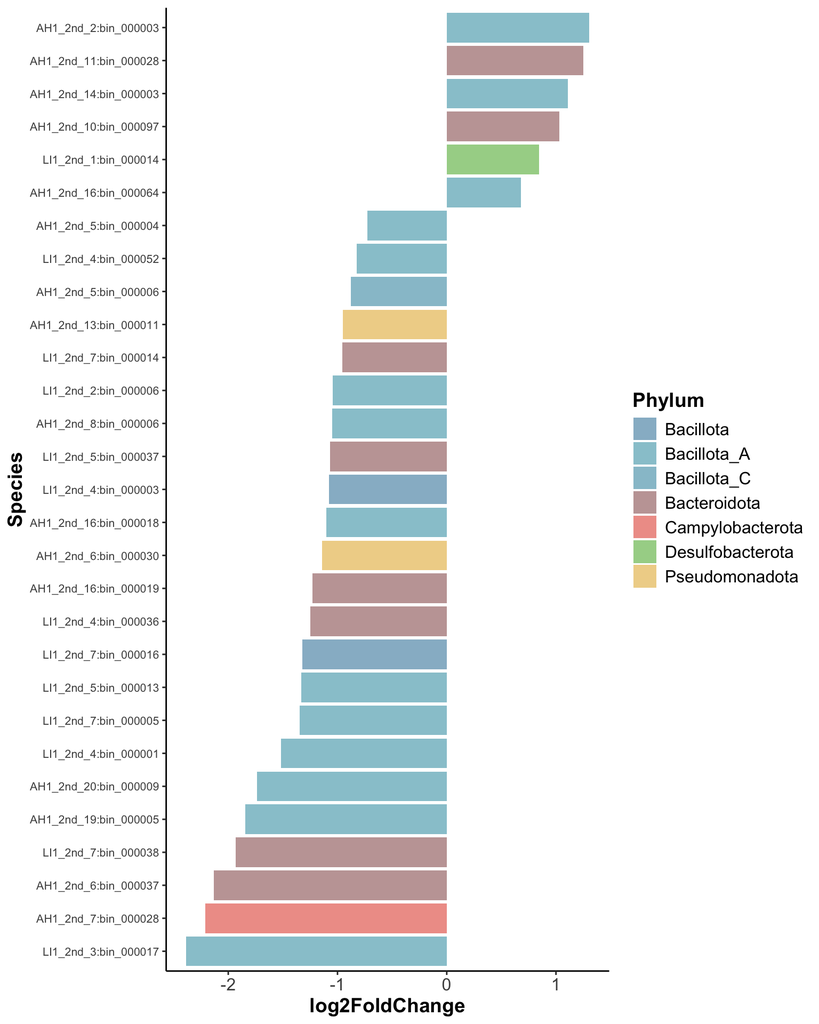

```r
ancombc_rand_table_mag%>%
  filter(lfc_typeTreatment>0)  %>%
  count(phylum, name = "sample_count") %>%
  arrange(desc(sample_count))
```

```
            phylum sample_count
1      Bacillota_A            3
2     Bacteroidota            2
3 Desulfobacterota            1
```

```r
ancombc_rand_table_mag%>%
  filter(lfc_typeTreatment<0)  %>%
  count(phylum, name = "sample_count") %>%
  arrange(desc(sample_count))
```

```
            phylum sample_count
1      Bacillota_A           11
2     Bacteroidota            6
3        Bacillota            2
4   Pseudomonadota            2
5      Bacillota_C            1
6 Campylobacterota            1
```

##### 9.2.1.4.2 Intervention vs cold control

```r
physeq_FMT2 <- subset_samples(physeq_all, type %in% c("Control", "Treatment") & time_point == "FMT2")
physeq_FMT2 <- prune_taxa(taxa_sums(physeq_FMT2)>0, physeq_FMT2)
```

```r
ancom_rand_output_cold_fmt2 = ancombc2(data = physeq_FMT2,
                  assay_name = "counts",
                  tax_level = NULL,
                  fix_formula = "type",
                  p_adj_method = "holm",
                  pseudo_sens = TRUE,
                  prv_cut =0,
                  lib_cut = 0,
                  s0_perc = 0.05,
                  group = "type",
                  struc_zero = TRUE,
                  neg_lb = FALSE,
                  alpha = 0.05,
                  n_cl = 2,
                  verbose = TRUE,
                  global = FALSE,
                  pairwise = FALSE,
                  dunnet = FALSE,
                  trend = FALSE,
                  iter_control = list(tol = 1e-5, max_iter = 20, verbose = FALSE),
                  em_control = list(tol = 1e-5, max_iter = 100),
                  mdfdr_control = list(fwer_ctrl_method = "holm", B = 100),
                  trend_control = NULL)
```

```r
save(ancom_rand_output_fmt2, file="data/ancom_rand_output_cold_fmt2.RData")
```

```r
load("data/ancom_rand_output_cold_fmt2.RData")
ancom_rand_output_cold_fmt2$res %>%
  dplyr::select(taxon, lfc_typeTreatment, p_typeTreatment) %>%
  filter(p_typeTreatment < 0.05)
```

```
                   taxon lfc_typeTreatment p_typeTreatment
1   AH1_2nd_2:bin_000034         1.9929787    0.0184868485
2  AH1_2nd_19:bin_000052         2.3104798    0.0315849384
3   LI1_2nd_7:bin_000012        -1.7895926    0.0237543551
4   AH1_2nd_8:bin_000051         1.3379258    0.0057066638
5  AH1_2nd_13:bin_000055         1.5191984    0.0038875900
6   LI1_2nd_7:bin_000053         1.4002356    0.0139050387
7  LI1_2nd_10:bin_000018         2.7538500    0.0005576674
8  AH1_2nd_15:bin_000021        -1.0818921    0.0255783857
9  AH1_2nd_19:bin_000001        -2.7702986    0.0001770141
10 AH1_2nd_18:bin_000047        -1.3652170    0.0382034073
11 AH1_2nd_12:bin_000012        -1.8894612    0.0168725768
12 AH1_2nd_13:bin_000011        -1.1976259    0.0228379695
13 AH1_2nd_20:bin_000075         0.9230526    0.0287989942
14 AH1_2nd_10:bin_000009         1.3469873    0.0071790764
15  AH1_2nd_5:bin_000004        -1.1362973    0.0104336512
16 AH1_2nd_19:bin_000005        -2.4927701    0.0281096246
17  AH1_2nd_1:bin_000005        -1.1145758    0.0498601997
18  AH1_2nd_2:bin_000003         1.4605986    0.0250928518
19 AH1_2nd_15:bin_000013        -1.0890325    0.0371924202
20  LI1_2nd_7:bin_000078         1.2016559    0.0287725935
21 AH1_2nd_20:bin_000042         1.1410513    0.0342880449
22  LI1_2nd_8:bin_000048         1.1265627    0.0405166867
23  LI1_2nd_8:bin_000019         1.4501067    0.0196764287
24  AH1_2nd_5:bin_000001         1.5930889    0.0346231445
25  LI1_2nd_1:bin_000006         0.9921931    0.0471546738
26 AH1_2nd_10:bin_000010         1.4464623    0.0346054372
27  AH1_2nd_1:bin_000003        -1.2930479    0.0332035603
```

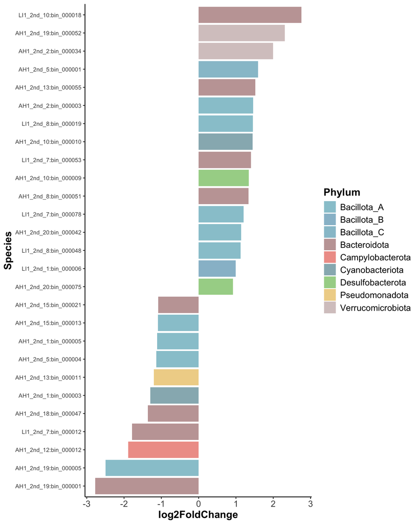

*Phyla of the significant MAGs in intervention group*

```r
ancombc_rand_table_mag%>%
  filter(lfc_typeTreatment>0)  %>%
  count(phylum, name = "sample_count") %>%
  arrange(desc(sample_count))
```

```
             phylum sample_count
1       Bacillota_A            5
2      Bacteroidota            4
3  Desulfobacterota            2
4 Verrucomicrobiota            2
5       Bacillota_B            1
6       Bacillota_C            1
7   Cyanobacteriota            1
```

*Phyla of the significant MAGs in cold control*

```r
ancombc_rand_table_mag%>%
  filter(lfc_typeTreatment<0)  %>%
  count(phylum, name = "sample_count") %>%
  arrange(desc(sample_count))
```

```
            phylum sample_count
1      Bacillota_A            4
2     Bacteroidota            4
3 Campylobacterota            1
4  Cyanobacteriota            1
5   Pseudomonadota            1
```

#### 9.2.1.5 Functional differences

*MCI*

```r
GIFTs_functions_community %>%
  rowMeans() %>%
  as_tibble(., rownames = "sample") %>%
  left_join(sample_metadata, by = join_by(sample == Tube_code)) %>%
  filter(time_point=="FMT2") %>%
  group_by(type) %>%
  summarise(MCI = mean(value), sd = sd(value))
```

```
# A tibble: 3 × 3
  type          MCI     sd
  <chr>       <dbl>  <dbl>
1 Control     0.352 0.0223
2 Hot_control 0.350 0.0293
3 Treatment   0.346 0.0255
```

```r
MCI_FMT2 <- GIFTs_functions_community %>%
  rowMeans() %>%
  as_tibble(., rownames = "sample") %>%
  left_join(sample_metadata, by = join_by(sample == Tube_code)) %>%
  filter(time_point == "FMT2")

shapiro.test(MCI_FMT2$value)
```

```
    Shapiro-Wilk normality test

data:  MCI_FMT2$value
W = 0.96248, p-value = 0.4203
```

```r
res.aov <- aov(value ~ type, data = MCI_FMT2)
summary(res.aov)
```

```
            Df  Sum Sq   Mean Sq F value Pr(>F)
type         2 0.00017 0.0000852   0.127  0.881
Residuals   24 0.01604 0.0006682
```

*Functional differences*

CC and CI

```r
significant_elements<-element_gift %>%
  filter(type %in% c("Control", "Treatment") & time_point == "FMT2") %>%
  select(-time_point, -type) %>%
  filter(rowSums(across(where(is.numeric), ~ . != 0)) > 0) %>%
  select(Tube_code, where( ~ is.numeric(.) && sum(.) > 0)) %>%
  left_join(sample_metadata[c(1, 7)], by = "Tube_code") %>%
  pivot_longer(-c(Tube_code, type),
               names_to = "trait",
               values_to = "value") %>%
  group_by(trait) %>%
  summarise(p_value = wilcox.test(value ~ type)$p.value) %>%
  mutate(p_adjust = p.adjust(p_value, method = "BH")) %>%
  filter(p_adjust < 0.05) %>%
  remove_rownames() %>%
  left_join(., uniqueGIFT_db, by=join_by("trait"=="Code_element"))
```

```r
element_gift_sig <- element_gift %>%
  select(Tube_code, all_of(intersect(
    significant_elements$trait,
    colnames(element_gift)
  ))) %>%
  left_join(., sample_metadata[c(1, 7)], by = join_by(Tube_code == Tube_code)) %>%
  filter(type!="Hot_control")

difference_table <- element_gift_sig %>%
  select(-Tube_code) %>%
  group_by(type) %>%
  summarise(across(everything(), mean)) %>%
  t() %>%
  row_to_names(row_number = 1) %>%
  as.data.frame() %>%
  mutate_if(is.character, as.numeric) %>%
  rownames_to_column(., "Elements") %>%
  left_join(.,uniqueGIFT_db[c(1,3,4)],by = join_by(Elements == Code_element)) %>%
  arrange(Function) %>%
  mutate(Difference=Control-Treatment)%>%
  mutate(group_color = ifelse(Difference <0, "Control","Treatment"))
```

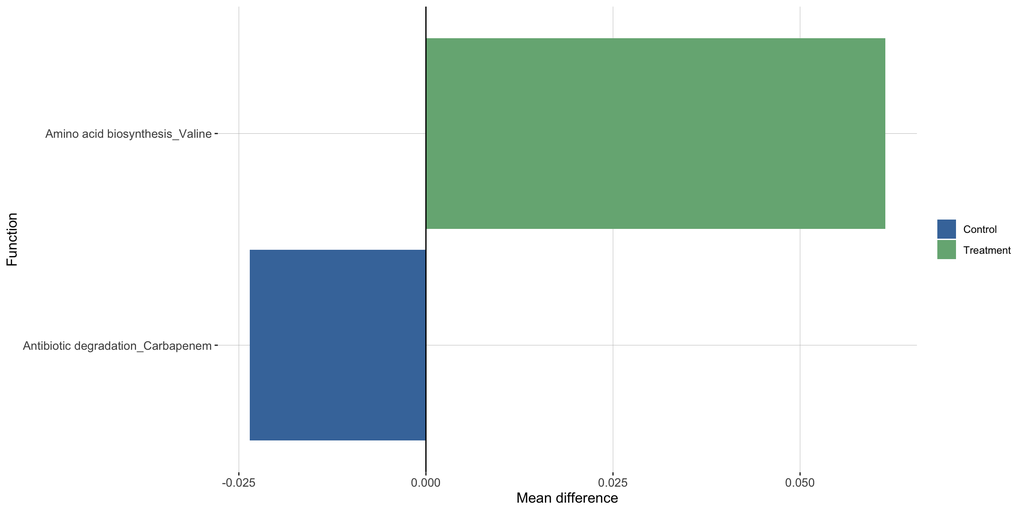

```r
difference_table %>%
  ggplot(aes(x=forcats::fct_reorder(Function,Difference), y=Difference, fill=group_color)) +
  geom_col() +
  scale_fill_manual(values=c("#4477AA","#76b183")) +
  geom_hline(yintercept=0) +
  coord_flip()+
  theme(axis.text = element_text(size = 10),
        axis.title = element_text(size = 12),
        legend.position = "right",
        legend.title = element_blank(),
        panel.background = element_blank(),
        panel.grid.major = element_line(size = 0.15, linetype = 'solid',
                                        colour = "grey"))+
  xlab("Function") +
  ylab("Mean difference")
```

CI and WC

```r
element_gift %>%
  filter(type %in% c("Hot_control", "Treatment") &
           time_point == "FMT2") %>%
  select(-time_point, -type) %>%
  filter(rowSums(across(where(is.numeric), ~ . != 0)) > 0) %>%
  select(Tube_code, where(~ is.numeric(.) && sum(.) > 0)) %>%
  left_join(sample_metadata[c(1, 7)], by = "Tube_code") %>%
  pivot_longer(-c(Tube_code,type), names_to = "trait", values_to = "value") %>%
  group_by(trait) %>%
  summarise(p_value = wilcox.test(value ~ type)$p.value) %>%
  mutate(p_adjust=p.adjust(p_value, method="BH")) %>%
  filter(p_adjust < 0.05)%>%
  remove_rownames()
```

```
# A tibble: 0 × 3
# ℹ 3 variables: trait <chr>, p_value <dbl>, p_adjust <dbl>
```

CC and WC

```r
element_gift %>%
  filter(type %in% c("Hot_control", "Control") &
           time_point == "FMT2") %>%
  select(-time_point, -type) %>%
  filter(rowSums(across(where(is.numeric), ~ . != 0)) > 0) %>%
  select(Tube_code, where(~ is.numeric(.) && sum(.) > 0)) %>%
  left_join(sample_metadata[c(1, 7)], by = "Tube_code") %>%
  pivot_longer(-c(Tube_code,type), names_to = "trait", values_to = "value") %>%
  group_by(trait) %>%
  summarise(p_value = wilcox.test(value ~ type)$p.value) %>%
  mutate(p_adjust=p.adjust(p_value, method="BH")) %>%
  filter(p_adjust < 0.05)%>%
  remove_rownames()
```

```
# A tibble: 0 × 3
# ℹ 3 variables: trait <chr>, p_value <dbl>, p_adjust <dbl>
```